# Model Creation for the Prediction of Student Performance and Improvement using Linear and Logistic Regression Methods

Alice Xiang

2025-04-07

# Introduction:

Education in adolescence is an important resource that can set them up to develop skills to succeed in adult life. Proficiency in language and mathematics is valuable for individual and societal success. A mixture of individual factors and organizational are associated with the success of students, and we intend to examine the influence of both types of factors on student test scores.

# Description of the Data

## The Raw Data

The original dataset is a collection of data from Snijders and Bosker (2012) adapted from the raw data from a 1989 study by H. P. Brandsma and W. M. Knuver containing information on 4106 pupils at 216 schools, found in the R mice library (1). The 14 variables of the adapted dataset are listed below, featuring demographic information on the students and schools and their pre- and post-test scores for language and mathematics. The information on the original study (2) shows that a random sample of 250 Dutch primary schools were selected within which all seventh grade students were tested on their proficiency in Dutch language and mathematics before and after an interval of one year. Information was also gathered on the student backgrounds and schoolrelated factors with an intention of measuring the effects of school and classrom characteristics on the progress of the students in these subjects.

sch - School number (numeric)

pup - Pupil ID (numeric)

iqv - IQ verbal (numeric)

iqp - IQ performal (numeric)

sex - Sex of pupil (categorical)

ses - SES score of pupil (numeric)

min - Minority member 0/1 (categorical)

rpg - Number of repeated groups, 0, 1, 2 (categorical)

lpr - language score PRE (numeric)

lpo - language score POST (numeric)

apr - Arithmetic score PRE (numeric)

apo - Arithmetic score POST (numeric)

den - Denomination classification 1-4 - at school level (categorical)

ssi - School SES indicator - at school level (numeric)

## The Analytic Dataset

sch - School number (numeric)

pup - Pupil ID (numeric)

tiqv - Transformed, standardized IQ verbal (numeric)

iqp - Standardized IQ performal (numeric)

sex - Sex of pupil (categorical)

tses - Transformed, standardized SES score of pupil (numeric)

min - Minority member 0/1 (categorical)

has_repeated_group - Whether or not there was a repeated group 0/1 (categorical)

tlpr - Transformed, standardized language score PRE (numeric)

tlpo - Transformed, standardized language score POST (numeric)

apr - Standardized Arithmetic score PRE (numeric)

tapo - Transformed, standardized Arithmetic score POST (numeric)

den - Denomination classification 1-4 - at school level (categorical)

tssi - Transformed, standardized School SES indicator - at school level (numeric)

tpost - Transformed, standardized post-score (transformed + standardized after calculating lpo+apo) (numeric)

A summary of the variables can be observed as follows:

```
## # A tibble: 2 × 2
##   l_chg_pos     n
##   <lgl>     <int>
## 1 FALSE       646
## 2 TRUE       3460
```

```
## # A tibble: 2 × 2
##   a_chg_pos     n
##   <lgl>     <int>
## 1 FALSE       431
## 2 TRUE       3675
```

```
##       pup            sch        sex      min      den           tlpr
##  Min.   :   1   Min.   :  1.0   0:2100   0:3868   1:1271   Min.   :-2.81814
##  1st Qu.:1073   1st Qu.: 66.0   1:2006   1: 238   2:1600   1st Qu.:-0.70954
##  Median :2128   Median :132.0                     3:1038   Median : 0.03653
##  Mean   :2121   Mean   :129.2                     4: 197   Mean   : 0.00000
##  3rd Qu.:3170   3rd Qu.:187.0                              3rd Qu.: 0.69505
##  Max.   :4214   Max.   :259.0                              Max.   : 2.57173
##       tses                tssi               tiqv               tlpo
##  Min.   :-2.171494   Min.   :-2.47302   Min.   :-3.14261   Min.   :-2.589462
##  1st Qu.:-0.579751   1st Qu.:-0.58918   1st Qu.:-0.67684   1st Qu.:-0.764652
##  Median : 0.001848   Median :-0.08691   Median : 0.03873   Median : 0.005185
##  Mean   : 0.000000   Mean   : 0.00000   Mean   : 0.00000   Mean   : 0.000000
##  3rd Qu.: 0.807671   3rd Qu.: 0.79825   3rd Qu.: 0.53429   3rd Qu.: 0.754953
##  Max.   : 1.752968   Max.   : 2.24266   Max.   : 3.47449   Max.   : 2.183419
##       tapo                apr                iqp               tpost
##  Min.   :-2.258335   Min.   :-3.13107   Min.   :-3.03163   Min.   :-2.562547
##  1st Qu.:-0.882041   1st Qu.:-0.84354   1st Qu.:-0.77656   1st Qu.:-0.742193
##  Median : 0.002267   Median : 0.01428   Median :-0.02488   Median :-0.006606
##  Mean   : 0.000000   Mean   : 0.00000   Mean   : 0.00000   Mean   : 0.000000
##  3rd Qu.: 0.805056   3rd Qu.: 0.87210   3rd Qu.: 0.72380   3rd Qu.: 0.800893
##  Max.   : 1.658299   Max.   : 2.30180   Max.   : 2.98187   Max.   : 2.092595
##  has_repeated_group l_chg    a_chg
##  0:3572             0: 646   0: 431
##  1: 534             1:3460   1:3675
##
##
##
##
```

As we can see, there are no longer missing values in any of the variables and all of the numeric variables are centered at 0. We can take a quick look at their distributions as follows:

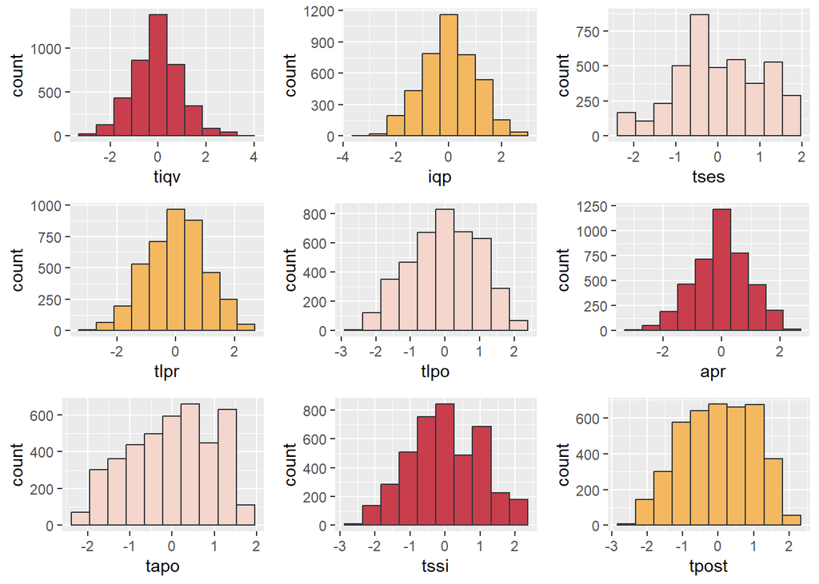

The transformed distributions, while not perfect, generally show patterns of being unimodally, symmetrically distributed around a mean of 0.

# Research Questions

With the analytic dataset created, the goal of this report is to answer two research questions. Language and arithmetic proficiency are often cumulatively considered in the assessment of the academic success of an individual, and is especially important as a measure of young adolescent students as an overall measure of their academic well-being. As such, in the analytic dataset, the language and arithmetic post-scores were combined into a total post-test score which will be used as a response variable for modeling purposes.

Another question that we want to consider is whether or not, on an individual basis, the student improved over the year between their pre-test and post-test. We will create two binary response variables, one for the language pre- and post-test and one for the arithemetic pre- and post-test, which represents whether or not the student improved (defined as an increase in their post-test score compared to their pre-test) over the past year.

We will use models to answer the following two research questions:

1. What factors, individual and on a school level, are associated with higher total post-test scores (language and arithmetic added together)?
2. What factors, individual and on a school level, are associated with increases in test scores for language and arithmetic after one year?

# Methodology

Multiple linear regression is a statistical method that uses several explanatory variables to predict the outcome of a continous response variable, and is an extension of ordinary least squares regression. It fits a linear relationship between the explanatory variables and the response. The assumptions for multiple regression include the following: the response variable is normally distributed and has a constant variance, the explanatory variables are nonrandom, the explanatory variables are noncorrelated, the explanatory variables have a linear relationship with the response, and the data is randomly collected and independent.

Logistic regression is a statistical method used for analyzing a dataset in which there are one or more independent variables that determine an outcome. The outcome is measured with a binary response variable, and is therefore appropriate for situations where linear regression cannot be used due to a dichotomous categorical response variable.The assuptions for a logistic regression include the following: the dependent variable should be binary, the independent variables should not be correlated, the log odds (the logit of the probability) and the independent variables should have a linear relationship, the sample size has to be sufficiently large, observations must be independent. Unlike multiple linear analysis, due to a categorical response, logistic regression does not require a normally distributed response variable with a constant variance. Outliers for both the linear and logistic regression model can have a significant effect on the results, and as such should be examined before and after the model’s creation.

K-fold cross-validation is a statistical technique where data is split into k folds and then iteratively split into testing and training data which is then used to assess the predictive power of a model. It ensures the use of all datapoints and can help adjust for variability and keep the model from overfitting any one fold, leading to a more robust final result. We will use 5-fold cross validation to test the predictive performance of both the multiple linear regression and logistic regression models.

# Linear Regression

We intend to create a linear regression model to identify factors that impact the total post-score of the students and quantify their effects. The predictors identified in the initial round of feature selection done in the previous analysis were apr, tlpr, tiqv, iqp, tses, rpg, tssi, den, min, and sex. We will look at the pairwise correlation plots of the numeric variables below.

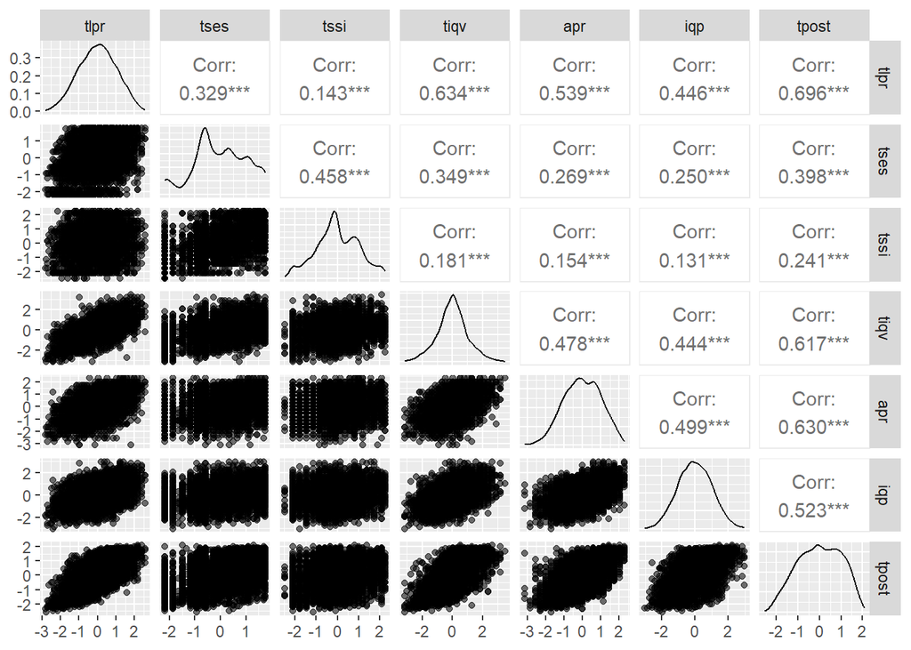

## Main effect models

We will create a full model with all the selected predictors and perform stepwise selection to remove certain predictors based on their AIC value.

```r
kable(summary(full_model)$coef, caption ="Full Main Effects Linear Model Parameter Estimates")
```

Full Main Effects Linear Model Parameter Estimates

|  | Estimate | Std. Error | t value | Pr(>\|t\|) |
| --- | --- | --- | --- | --- |
| (Intercept) | -0.1308347 | 0.0200139 | -6.537187 | 0.0000000 |
| sex1 | 0.0668590 | 0.0189540 | 3.527429 | 0.0004242 |
| min1 | 0.0524918 | 0.0412210 | 1.273421 | 0.2029408 |
| den2 | 0.2517373 | 0.0225912 | 11.143168 | 0.0000000 |
| den3 | 0.0911318 | 0.0248985 | 3.660127 | 0.0002553 |
| den4 | 0.1054136 | 0.0467413 | 2.255254 | 0.0241700 |
| tlpr | 0.3266385 | 0.0131490 | 24.841355 | 0.0000000 |
| tses | 0.0926378 | 0.0112352 | 8.245346 | 0.0000000 |
| tssi | 0.0619850 | 0.0106659 | 5.811492 | 0.0000000 |
| tiqv | 0.1672796 | 0.0127085 | 13.162781 | 0.0000000 |
| apr | 0.2524611 | 0.0118620 | 21.283210 | 0.0000000 |
| iqp | 0.1275108 | 0.0113208 | 11.263382 | 0.0000000 |
| has_repeated_group1 | -0.2388497 | 0.0288936 | -8.266537 | 0.0000000 |

The stepwise model only removed the parameter of min, which represents whether or not the student is of a minority group. This was the same feature that was identified in the initial exploratory analysis as having a nonsignificant p-value when a linear model for post was created with the same predictors using the mice imputed dataset.

We can now check the assumptions of both models, looking for evidence of violations to normality, homoscedasticity, and multicollinearity.

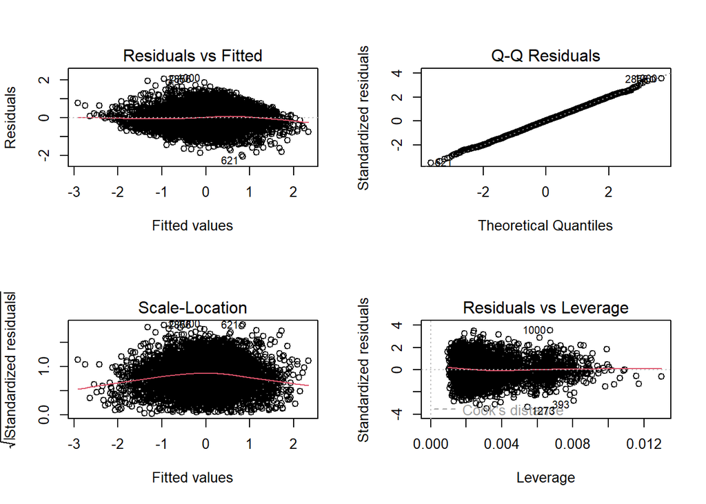

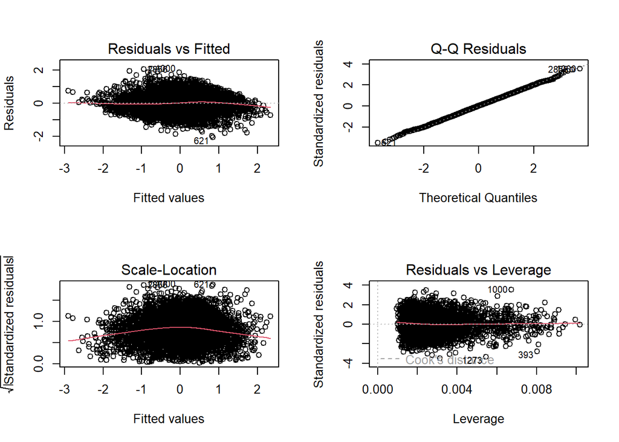

|  | GVIF | Df | GVIF^(1/(2*Df)) |
| --- | --- | --- | --- |
| sex | 1.051641 | 1 | 1.025495 |
| min | 1.086965 | 1 | 1.042576 |
| den | 1.104577 | 3 | 1.016715 |
| tlpr | 2.025026 | 1 | 1.423034 |
| tses | 1.478446 | 1 | 1.215914 |
| tssi | 1.332431 | 1 | 1.154310 |
| tiqv | 1.891633 | 1 | 1.375366 |
| apr | 1.648014 | 1 | 1.283750 |
| iqp | 1.501076 | 1 | 1.225184 |
| has_repeated_group | 1.106545 | 1 | 1.051924 |

|  | GVIF | Df | GVIF^(1/(2*Df)) |
| --- | --- | --- | --- |
| sex | 1.051535 | 1 | 1.025443 |
| den | 1.091854 | 3 | 1.014754 |
| tlpr | 2.024256 | 1 | 1.422764 |
| tses | 1.457989 | 1 | 1.207472 |
| tssi | 1.329791 | 1 | 1.153166 |
| tiqv | 1.870996 | 1 | 1.367844 |
| apr | 1.645849 | 1 | 1.282906 |
| iqp | 1.501039 | 1 | 1.225169 |
| has_repeated_group | 1.105350 | 1 | 1.051356 |

The Q-Q plot is largely linear and therefore shows evidence of normality, and the VIF values do not show evidence of multicollinearity that requires adjustment to the predictors in either model. However, the residuals vs. fitted plots do show a “football” shape, having smaller variances at both ends and much larger variances in the middle rather than completely random scatter above the line x = 0. This could evidence against the variance being constant, which would violate the assumption of homogeneity of variance and can lead to bias in the predictions of the linear regression model.

However, with a large dataset, it’s also possible that the narrowness observed for extreme values at each end is due to there being much fewer observations at those points. This would naturally affect the visual spread of the residuals compared to points along the x axis where there are many more observations, even in a case where all observations technically have the same variance. We will proceed with the rest of the linear regression analysis with caution.

Using these two candidate models, we will compare their performance using 5-fold cross-validation.

```
## Linear Regression
##
## 4106 samples
##   10 predictor
##
## No pre-processing
## Resampling: Cross-Validated (5 fold)
## Summary of sample sizes: 3285, 3285, 3285, 3284, 3285
## Resampling results:
##
##   RMSE       Rsquared   MAE
##   0.5926082  0.6489202  0.473492
##
## Tuning parameter 'intercept' was held constant at a value of TRUE
```

```
## Linear Regression
##
## 4106 samples
##    9 predictor
##
## No pre-processing
## Resampling: Cross-Validated (5 fold)
## Summary of sample sizes: 3285, 3285, 3285, 3285, 3284
## Resampling results:
##
##   RMSE      Rsquared   MAE
##   0.592711  0.6489602  0.4737837
##
## Tuning parameter 'intercept' was held constant at a value of TRUE
```

Comparing across the RMSE, the R-squared, and the MAE, we observe very small differences between the performances of the full and regression models. The test RMSE of around 0.593 for both models indicates that the predictions of the standardized total post-score were off by an average of 0.593. Using the standard deviation (118.3467) from the transformed post-test score and the optimal lambda (1.515152) that was used to transform its values in order to put this back into the meaningful units of the original test score, this translates to predicted total post-test scores that were on average, off by about 8.85 points.

With such similar performances between the two models, on principles of parsimony, the information given suggests the stepwise model as the best linear model for predicting the total post-test score.

# Interaction models

To continue our investigation, we will go through a similar process to the above but with a full model including all two-way interactions and then run a stepwise variable selection algorithm to create a second model.

Full Model Parameter Estimates (including 2-way Interaction Terms)

|  | Estimate | Std. Error | t value | Pr(>\|t\|) |
| --- | --- | --- | --- | --- |
| (Intercept) | -0.1064979 | 0.0274184 | -3.8841685 | 0.0001043 |
| sex1 | 0.0834443 | 0.0359217 | 2.3229521 | 0.0202313 |
| min1 | 0.0301980 | 0.0857932 | 0.3519856 | 0.7248675 |
| den2 | 0.2680596 | 0.0347261 | 7.7192615 | 0.0000000 |
| den3 | 0.0693947 | 0.0375079 | 1.8501350 | 0.0643672 |
| den4 | 0.0061992 | 0.0911167 | 0.0680359 | 0.9457604 |
| tlpr | 0.3567131 | 0.0289933 | 12.3032765 | 0.0000000 |
| tses | 0.0867820 | 0.0244123 | 3.5548412 | 0.0003825 |
| tssi | 0.0811018 | 0.0221348 | 3.6639911 | 0.0002515 |
| tiqv | 0.1636655 | 0.0276889 | 5.9108769 | 0.0000000 |
| apr | 0.2416855 | 0.0255163 | 9.4718254 | 0.0000000 |
| iqp | 0.1369337 | 0.0246568 | 5.5535907 | 0.0000000 |
| has_repeated_group1 | -0.1968657 | 0.0613606 | -3.2083392 | 0.0013455 |
| sex1:min1 | -0.0736986 | 0.0862125 | -0.8548486 | 0.3926858 |
| sex1:den2 | -0.0186334 | 0.0464428 | -0.4012110 | 0.6882861 |
| sex1:den3 | 0.0299292 | 0.0511305 | 0.5853495 | 0.5583455 |
| sex1:den4 | -0.1077445 | 0.0987973 | -1.0905609 | 0.2755313 |
| sex1:tlpr | -0.0003232 | 0.0267767 | -0.0120692 | 0.9903710 |
| sex1:tses | -0.0068189 | 0.0232842 | -0.2928536 | 0.7696491 |
| sex1:tssi | 0.0028004 | 0.0219202 | 0.1277525 | 0.8983512 |
| sex1:tiqv | -0.0193043 | 0.0259309 | -0.7444518 | 0.4566466 |
| sex1:apr | -0.0134254 | 0.0243814 | -0.5506387 | 0.5819119 |
| sex1:iqp | 0.0476249 | 0.0230989 | 2.0617852 | 0.0392922 |
| sex1:has_repeated_group1 | -0.0661562 | 0.0609397 | -1.0856009 | 0.2777205 |
| min1:den2 | -0.0329569 | 0.1106262 | -0.2979121 | 0.7657856 |
| min1:den3 | 0.2261507 | 0.1075253 | 2.1032317 | 0.0355074 |
| min1:den4 | -0.2282251 | 0.2883784 | -0.7914081 | 0.4287524 |
| min1:tlpr | 0.0079044 | 0.0608150 | 0.1299743 | 0.8965933 |
| min1:tses | -0.0586789 | 0.0437015 | -1.3427185 | 0.1794388 |
| min1:tssi | -0.0196607 | 0.0405581 | -0.4847537 | 0.6278774 |
| min1:tiqv | -0.0335875 | 0.0532779 | -0.6304205 | 0.5284553 |
| min1:apr | 0.0358244 | 0.0555244 | 0.6452014 | 0.5188334 |
| min1:iqp | -0.0324949 | 0.0557085 | -0.5833024 | 0.5597224 |
| min1:has_repeated_group1 | -0.0706659 | 0.1069767 | -0.6605724 | 0.5089243 |
| den2:tlpr | -0.0500320 | 0.0324534 | -1.5416539 | 0.1232362 |
| den3:tlpr | -0.0166327 | 0.0354607 | -0.4690444 | 0.6390633 |
| den4:tlpr | -0.0009627 | 0.0662051 | -0.0145406 | 0.9883994 |
| den2:tses | 0.0072369 | 0.0273919 | 0.2641977 | 0.7916411 |
| den3:tses | 0.0057750 | 0.0305631 | 0.1889528 | 0.8501394 |
| den4:tses | 0.0348950 | 0.0596058 | 0.5854295 | 0.5582917 |
| den2:tssi | -0.0592745 | 0.0251548 | -2.3563879 | 0.0185012 |
| den3:tssi | 0.0005565 | 0.0295975 | 0.0188021 | 0.9849999 |
| den4:tssi | 0.1420138 | 0.0616173 | 2.3047714 | 0.0212300 |
| den2:tiqv | 0.0495857 | 0.0319241 | 1.5532374 | 0.1204449 |
| den3:tiqv | 0.0307880 | 0.0337703 | 0.9116894 | 0.3619868 |
| den4:tiqv | -0.0150837 | 0.0621569 | -0.2426714 | 0.8082723 |
| den2:apr | 0.0540228 | 0.0289048 | 1.8689948 | 0.0616960 |
| den3:apr | -0.0033687 | 0.0322360 | -0.1045000 | 0.9167778 |
| den4:apr | 0.0446393 | 0.0601225 | 0.7424725 | 0.4578444 |
| den2:iqp | -0.0494948 | 0.0279247 | -1.7724345 | 0.0763980 |
| den3:iqp | -0.0551015 | 0.0307824 | -1.7900305 | 0.0735241 |
| den4:iqp | -0.0677145 | 0.0572862 | -1.1820404 | 0.2372594 |
| den2:has_repeated_group1 | -0.1269193 | 0.0687168 | -1.8469906 | 0.0648218 |
| den3:has_repeated_group1 | -0.1092569 | 0.0819053 | -1.3339425 | 0.1822981 |
| den4:has_repeated_group1 | -0.0224686 | 0.1555317 | -0.1444630 | 0.8851421 |
| tlpr:tses | -0.0086364 | 0.0161707 | -0.5340745 | 0.5933194 |
| tlpr:tssi | 0.0152900 | 0.0149937 | 1.0197620 | 0.3079026 |
| tlpr:tiqv | -0.0258014 | 0.0133845 | -1.9277052 | 0.0539620 |
| tlpr:apr | -0.0033486 | 0.0148403 | -0.2256402 | 0.8214927 |
| tlpr:iqp | -0.0130072 | 0.0157016 | -0.8283983 | 0.4074940 |
| tlpr:has_repeated_group1 | -0.0830017 | 0.0413268 | -2.0084202 | 0.0446653 |
| tses:tssi | -0.0172101 | 0.0104507 | -1.6467857 | 0.0996801 |
| tses:tiqv | -0.0052787 | 0.0154559 | -0.3415336 | 0.7327197 |
| tses:apr | 0.0085199 | 0.0145080 | 0.5872540 | 0.5570661 |
| tses:iqp | 0.0170547 | 0.0137498 | 1.2403640 | 0.2149130 |
| tses:has_repeated_group1 | 0.0004933 | 0.0354527 | 0.0139157 | 0.9888979 |
| tssi:tiqv | -0.0076874 | 0.0147291 | -0.5219199 | 0.6017548 |
| tssi:apr | -0.0175288 | 0.0139338 | -1.2580080 | 0.2084618 |
| tssi:iqp | -0.0135971 | 0.0134064 | -1.0142289 | 0.3105344 |
| tssi:has_repeated_group1 | -0.0143241 | 0.0331753 | -0.4317696 | 0.6659320 |
| tiqv:apr | -0.0166028 | 0.0157760 | -1.0524064 | 0.2926762 |
| tiqv:iqp | 0.0029304 | 0.0147826 | 0.1982330 | 0.8428728 |
| tiqv:has_repeated_group1 | -0.0407572 | 0.0406055 | -1.0037374 | 0.3155654 |
| apr:iqp | 0.0009278 | 0.0131381 | 0.0706159 | 0.9437069 |
| apr:has_repeated_group1 | -0.0351618 | 0.0363686 | -0.9668194 | 0.3336923 |
| iqp:has_repeated_group1 | 0.0249920 | 0.0353212 | 0.7075648 | 0.4792565 |

Stepwise Selected Model Parameter Estimates (including 2-way Interaction Terms

|  | Estimate | Std. Error | t value | Pr(>\|t\|) |
| --- | --- | --- | --- | --- |
| (Intercept) | -0.0938870 | 0.0214198 | -4.3831819 | 0.0000120 |
| sex1 | 0.0673288 | 0.0188566 | 3.5705675 | 0.0003603 |
| min1 | 0.0196275 | 0.0670235 | 0.2928444 | 0.7696560 |
| den2 | 0.2432223 | 0.0231820 | 10.4918435 | 0.0000000 |
| den3 | 0.0749242 | 0.0257478 | 2.9099217 | 0.0036347 |
| den4 | -0.0477896 | 0.0696477 | -0.6861614 | 0.4926503 |
| tlpr | 0.3374911 | 0.0135927 | 24.8288267 | 0.0000000 |
| tses | 0.0924705 | 0.0115384 | 8.0141386 | 0.0000000 |
| tssi | 0.0746634 | 0.0163702 | 4.5609465 | 0.0000052 |
| tiqv | 0.1721524 | 0.0126799 | 13.5768219 | 0.0000000 |
| apr | 0.2550977 | 0.0118231 | 21.5761823 | 0.0000000 |
| iqp | 0.1087985 | 0.0142298 | 7.6458219 | 0.0000000 |
| has_repeated_group1 | -0.2947357 | 0.0337451 | -8.7341685 | 0.0000000 |
| sex1:iqp | 0.0325983 | 0.0186337 | 1.7494267 | 0.0802924 |
| min1:den2 | -0.0932103 | 0.1021298 | -0.9126656 | 0.3614723 |
| min1:den3 | 0.1838061 | 0.1017406 | 1.8066155 | 0.0708959 |
| min1:den4 | -0.2264644 | 0.2773336 | -0.8165775 | 0.4142176 |
| min1:tses | -0.0737487 | 0.0353519 | -2.0861338 | 0.0370285 |
| den2:tssi | -0.0533074 | 0.0221998 | -2.4012563 | 0.0163834 |
| den3:tssi | 0.0023204 | 0.0260210 | 0.0891761 | 0.9289463 |
| den4:tssi | 0.1402723 | 0.0532475 | 2.6343438 | 0.0084619 |
| tlpr:tiqv | -0.0389074 | 0.0084378 | -4.6111006 | 0.0000041 |
| tlpr:has_repeated_group1 | -0.1138520 | 0.0314174 | -3.6238571 | 0.0002938 |
| tses:tssi | -0.0145763 | 0.0095299 | -1.5295377 | 0.1262087 |
| tssi:apr | -0.0157276 | 0.0096419 | -1.6311683 | 0.1029320 |

The main and interaction effects identified with p-values less than an alpha level of 0.05 by the full interaction model are the following: Main effects: sex, den, tlpr, tses, tssi, tiqv, apr, iqp, has_repeated_group Interaction effects: sex:iqp, min:den, den:tssi, tlpr:has_repeated_group

Once again, we will look at the residual plots and VIF to check for violations to the assumptions of linear regression.

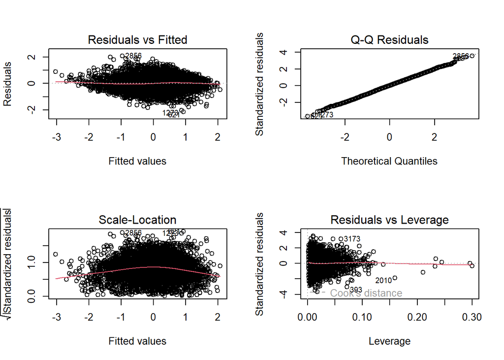

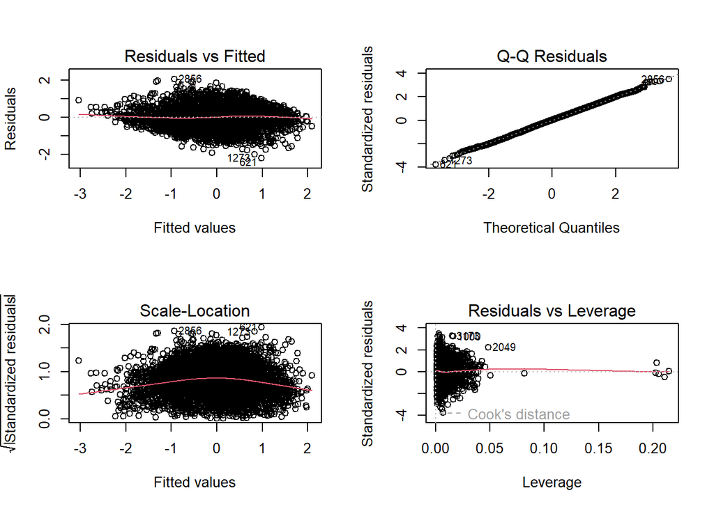

```
## there are higher-order terms (interactions) in this model
## consider setting type = 'predictor'; see ?vif
```

|  | GVIF | Df | GVIF^(1/(2*Df)) |
| --- | --- | --- | --- |
| sex | 3.809247 | 1 | 1.951729 |
| min | 4.748375 | 1 | 2.179077 |
| den | 23.809346 | 3 | 1.696125 |
| tlpr | 9.928978 | 1 | 3.151028 |
| tses | 7.039262 | 1 | 2.653161 |
| tssi | 5.787093 | 1 | 2.405638 |
| tiqv | 9.055627 | 1 | 3.009257 |
| apr | 7.690275 | 1 | 2.773134 |
| iqp | 7.180935 | 1 | 2.679727 |
| has_repeated_group | 5.032781 | 1 | 2.243386 |
| sex:min | 2.248965 | 1 | 1.499655 |
| sex:den | 19.999647 | 3 | 1.647544 |
| sex:tlpr | 4.071754 | 1 | 2.017859 |
| sex:tses | 3.155137 | 1 | 1.776271 |
| sex:tssi | 2.725603 | 1 | 1.650940 |
| sex:tiqv | 3.767442 | 1 | 1.940990 |
| sex:apr | 3.162665 | 1 | 1.778388 |
| sex:iqp | 2.883590 | 1 | 1.698114 |
| sex:has_repeated_group | 1.984716 | 1 | 1.408799 |
| min:den | 3.469597 | 3 | 1.230401 |
| min:tlpr | 4.163131 | 1 | 2.040375 |
| min:tses | 2.830600 | 1 | 1.682439 |
| min:tssi | 2.008851 | 1 | 1.417339 |
| min:tiqv | 4.360568 | 1 | 2.088197 |
| min:apr | 2.538613 | 1 | 1.593302 |
| min:iqp | 2.627520 | 1 | 1.620963 |
| min:has_repeated_group | 1.978804 | 1 | 1.406699 |
| den:tlpr | 27.074722 | 3 | 1.732849 |
| den:tses | 11.067287 | 3 | 1.492818 |
| den:tssi | 15.308579 | 3 | 1.575757 |
| den:tiqv | 22.032438 | 3 | 1.674340 |
| den:apr | 17.173784 | 3 | 1.606242 |
| den:iqp | 12.455987 | 3 | 1.522520 |
| den:has_repeated_group | 6.129867 | 3 | 1.352826 |
| tlpr:tses | 3.270337 | 1 | 1.808407 |
| tlpr:tssi | 2.853894 | 1 | 1.689347 |
| tlpr:tiqv | 2.955831 | 1 | 1.719253 |
| tlpr:apr | 2.890235 | 1 | 1.700069 |
| tlpr:iqp | 3.311464 | 1 | 1.819743 |
| tlpr:has_repeated_group | 3.110993 | 1 | 1.763801 |
| tses:tssi | 1.437101 | 1 | 1.198792 |
| tses:tiqv | 3.235540 | 1 | 1.798761 |
| tses:apr | 2.599010 | 1 | 1.612144 |
| tses:iqp | 2.309144 | 1 | 1.519587 |
| tses:has_repeated_group | 2.260765 | 1 | 1.503584 |
| tssi:tiqv | 2.822146 | 1 | 1.679924 |
| tssi:apr | 2.341525 | 1 | 1.530204 |
| tssi:iqp | 2.108531 | 1 | 1.452078 |
| tssi:has_repeated_group | 1.749666 | 1 | 1.322749 |
| tiqv:apr | 3.332620 | 1 | 1.825546 |
| tiqv:iqp | 3.171794 | 1 | 1.780953 |
| tiqv:has_repeated_group | 3.115000 | 1 | 1.764936 |
| apr:iqp | 2.238348 | 1 | 1.496111 |
| apr:has_repeated_group | 2.216783 | 1 | 1.488887 |
| iqp:has_repeated_group | 2.066145 | 1 | 1.437409 |

```
## there are higher-order terms (interactions) in this model
## consider setting type = 'predictor'; see ?vif
```

|  | GVIF | Df | GVIF^(1/(2*Df)) |
| --- | --- | --- | --- |
| sex | 1.054132 | 1 | 1.026709 |
| min | 2.910283 | 1 | 1.705955 |
| den | 2.957540 | 3 | 1.198087 |
| tlpr | 2.191604 | 1 | 1.480407 |
| tses | 1.579220 | 1 | 1.256670 |
| tssi | 3.178745 | 1 | 1.782903 |
| tiqv | 1.907127 | 1 | 1.380988 |
| apr | 1.658111 | 1 | 1.287677 |
| iqp | 2.401859 | 1 | 1.549793 |
| has_repeated_group | 1.528596 | 1 | 1.236364 |
| sex:iqp | 1.884477 | 1 | 1.372762 |
| min:den | 2.565254 | 3 | 1.170007 |
| min:tses | 1.860164 | 1 | 1.363878 |
| den:tssi | 7.024258 | 3 | 1.383885 |
| tlpr:tiqv | 1.179702 | 1 | 1.086141 |
| tlpr:has_repeated_group | 1.805575 | 1 | 1.343717 |
| tses:tssi | 1.200084 | 1 | 1.095483 |
| tssi:apr | 1.125975 | 1 | 1.061119 |

Finally, we will perform 5-fold cross-validation with the interaction models.

```
## Linear Regression
##
## 4106 samples
##   10 predictor
##
## No pre-processing
## Resampling: Cross-Validated (5 fold)
## Summary of sample sizes: 3285, 3285, 3285, 3284, 3285
## Resampling results:
##
##   RMSE       Rsquared   MAE
##   0.5944228  0.6469267  0.4742027
##
## Tuning parameter 'intercept' was held constant at a value of TRUE
```

```
## Linear Regression
##
## 4106 samples
##   10 predictor
##
## No pre-processing
## Resampling: Cross-Validated (5 fold)
## Summary of sample sizes: 3285, 3285, 3285, 3285, 3284
## Resampling results:
##
##   RMSE       Rsquared  MAE
##   0.5903401  0.651934  0.4711809
##
## Tuning parameter 'intercept' was held constant at a value of TRUE
```

Once again, the results appear similar to the main effect models.

## Model Selection

We will assess the four models with a few goodness of fit measures.

Goodness-of-fit Measures of Candidate Models

|  | SSE | R.sq | R.adj | AIC | BIC |
| --- | --- | --- | --- | --- | --- |
| Full Main Effect Model | 1434.527 | 0.6505416 | 0.6495171 | -4291.929 | -4209.766 |
| Stepwise Main Effect Model | 1435.095 | 0.6504032 | 0.6494639 | -4292.302 | -4216.460 |
| Full Interaction Model | 1400.588 | 0.6588094 | 0.6524597 | -4264.239 | -3783.903 |
| Stepwise Interaction Model | 1412.310 | 0.6559537 | 0.6539304 | -4332.016 | -4174.011 |

Once again, the statistics across the board are all quite similar; this, combined with similar performances with 5-fold cross-validation, suggest that the four models perform similarly in terms of predictive potential. The adjusted R-square and AIC values recommend the stepwise interaction model, while the BIC recommends the stepwise main effect model.

Just to check, I will try one last reduced model where all nonsignificant interaction effects from the stepwise interaction model are removed, starting from the one with the greatest p-value and continuing to remove terms one at a time and rerunning until a model is created with all factors having a p-value under the alpha of 0.05.

This ends up giving the following predictors: Main effects: sex, min, den, tlpr, tses, tssi, tiqv, apr, iqp, has_repeated_group Interaction effects: den:tssi, tlpr:tiqv, tlpr:has_repeated_group, tssi:apr

```
## Linear Regression
##
## 4106 samples
##   10 predictor
##
## No pre-processing
## Resampling: Cross-Validated (5 fold)
## Summary of sample sizes: 3285, 3284, 3284, 3285, 3286
## Resampling results:
##
##   RMSE       Rsquared   MAE
##   0.5889761  0.6528472  0.4701559
##
## Tuning parameter 'intercept' was held constant at a value of TRUE
```

Based on this, we do get a slightly smaller RMSE value compared to the other models, but the measures are still very similar. Once again, we can look at the goodness of fit statistics in comparison with our other candidate models.

Goodness-of-fit Measures of Candidate Models

|  | SSE | R.sq | R.adj | AIC | BIC |
| --- | --- | --- | --- | --- | --- |
| Full Main Effect Model | 1434.527 | 0.6505416 | 0.6495171 | -4291.929 | -4209.766 |
| Stepwise Main Effect Model | 1435.095 | 0.6504032 | 0.6494639 | -4292.302 | -4216.460 |
| Full Interaction Model | 1400.588 | 0.6588094 | 0.6524597 | -4264.239 | -3783.903 |
| Stepwise Interaction Model | 1412.310 | 0.6559537 | 0.6539304 | -4332.016 | -4174.011 |
| Simplified Stepwise Interaction Model | 1417.166 | 0.6547708 | 0.6532503 | -4329.923 | -4209.839 |

The adjusted R-squared and AIC values still recommend the original stepwise interaction model. However, the BIC value for the simplified stepwise interaction model is better than the original stepwise interaction model and the original full main effects model, although the stepwise main effects model still performs better than it according to its BIC.

The models all seem to perform very similarly. As such, our first recommendation would be the simplest model, that being the stepwise main effects model, for having the fewest predictors and no interaction effects. The differences in performance appear small enough for it to not differ substantially to the other models for predictive purposes. However, for analytic purposes and in order to examine the ways that the features affect the response with more depth, my second recommendation would be the stepwise interaction or simplified stepwise interaction models. These include significant interaction terms and allow for the modeling of the effects of certain features on the response changing depending on other features.

The parameter estimates of the stepwise selected main effects model are as follows:

|  | Estimate | Std. Error | t value | Pr(>\|t\|) |
| --- | --- | --- | --- | --- |
| (Intercept) | -0.1261515 | 0.0196746 | -6.411893 | 0.0000000 |
| sex1 | 0.0666164 | 0.0189545 | 3.514540 | 0.0004453 |
| den2 | 0.2486549 | 0.0224628 | 11.069615 | 0.0000000 |
| den3 | 0.0895137 | 0.0248680 | 3.599555 | 0.0003225 |
| den4 | 0.1039741 | 0.0467312 | 2.224940 | 0.0261396 |
| tlpr | 0.3263121 | 0.0131475 | 24.819363 | 0.0000000 |
| tses | 0.0909549 | 0.0111580 | 8.151532 | 0.0000000 |
| tssi | 0.0613804 | 0.0106562 | 5.760079 | 0.0000000 |
| tiqv | 0.1655893 | 0.0126400 | 13.100441 | 0.0000000 |
| apr | 0.2530087 | 0.0118551 | 21.341785 | 0.0000000 |
| iqp | 0.1274391 | 0.0113215 | 11.256336 | 0.0000000 |
| has_repeated_group1 | -0.2376406 | 0.0288801 | -8.228511 | 0.0000000 |

All of the main effects from the original data are included except for min, which had two levels to represent whether or not the student was a minority. This model is based on the transformed, standardized values of the variables. However, the signs of the parameters should be unchanged. From this model, we can see that higher values for the pre-test scores for arithemetic and language, higher values of individual socioeconomic scores and school socioeconomic status, and higher IQ scores are positively associated with the total post-test score. For the categorical features, being part of the group sex = 1 meant higher average post-test scores, and the denomination classifications of 2-4 performed better than the denomination classified as 1. The only feature to have a negative parameter estimate is has_repeated_group, where the presence of a repeated group for the individual is negatively associated with their post-test score.

# Logistic Regression

Our second research question examines the question of whether or not an individual student has improved from their pre-test score to their post-test score. We created two binary response variables that measure whether or not an individual had a positive (greater than 0) change in score from their post-test score to their pre-test score, one for their arithmetic scores and one for language. We will use these variables to create two final logistic models.

Language Score Improvement: Yes or No

| l_chg | n |
| --- | --- |
| 0 | 646 |
| 1 | 3460 |

Arithmetic Score Improvement: Yes or No

| a_chg | n |
| --- | --- |
| 0 | 431 |
| 1 | 3675 |

Combined Score Improvement

| l_chg | a_chg | n |
| --- | --- | --- |
| 0 | 0 | 156 |
| 0 | 1 | 490 |
| 1 | 0 | 275 |
| 1 | 1 | 3185 |

Looking across these tables, we see that most students improved between their pre- and post-test scores for both arithmetic and language, which is expected. The table of the combinations of values for a_chg and l_chg show that 156 students showed no improvement in either subject, 490 showed improvement in arithmetic but not language, 275 showed improvement in language but not arithmetic, and 3185 showed improvement in both subjects.

# Main Effect Models

We’ll begin by fitting two full main effect logistic regression models.

Language Improvement Logistic Full Main Effects Model Parameter Estimates

|  | Estimate | Std. Error | z value | Pr(>\|z\|) |
| --- | --- | --- | --- | --- |
| (Intercept) | 1.6361975 | 0.0957575 | 17.086893 | 0.0000000 |
| sex1 | 0.6883649 | 0.0957025 | 7.192757 | 0.0000000 |
| min1 | 0.3101520 | 0.1864894 | 1.663107 | 0.0962909 |
| den2 | 0.2228432 | 0.1139980 | 1.954799 | 0.0506068 |
| den3 | -0.1227161 | 0.1161427 | -1.056597 | 0.2906954 |
| den4 | 0.1635197 | 0.2613480 | 0.625678 | 0.5315262 |
| tses | 0.1077922 | 0.0566879 | 1.901501 | 0.0572364 |
| tssi | 0.0652368 | 0.0536795 | 1.215302 | 0.2242508 |
| tiqv | 0.1769375 | 0.0589754 | 3.000193 | 0.0026981 |
| apr | -0.1188408 | 0.0622530 | -1.908999 | 0.0562622 |
| iqp | -0.1289585 | 0.0581090 | -2.219252 | 0.0264696 |
| has_repeated_group1 | -0.3020738 | 0.1189820 | -2.538819 | 0.0111227 |
| tapo | 0.8997798 | 0.0726812 | 12.379821 | 0.0000000 |

Arithmetic Improvement Logistic Full Main Effects Model Parameter Estimates

|  | Estimate | Std. Error | z value | Pr(>\|z\|) |
| --- | --- | --- | --- | --- |
| (Intercept) | 3.0768835 | 0.1396567 | 22.0317616 | 0.0000000 |
| sex1 | -0.5606782 | 0.1185947 | -4.7276856 | 0.0000023 |
| min1 | 0.2706972 | 0.2094831 | 1.2922149 | 0.1962827 |
| den2 | 0.2330302 | 0.1378617 | 1.6903179 | 0.0909671 |
| den3 | 0.0932450 | 0.1440809 | 0.6471712 | 0.5175212 |
| den4 | 0.3407571 | 0.3798616 | 0.8970559 | 0.3696891 |
| tses | 0.0545382 | 0.0703005 | 0.7757869 | 0.4378748 |
| tssi | 0.2195656 | 0.0653789 | 3.3583529 | 0.0007841 |
| tiqv | -0.0549398 | 0.0824169 | -0.6666082 | 0.5050224 |
| tlpr | -0.0926403 | 0.0907471 | -1.0208619 | 0.3073199 |
| iqp | 0.4949656 | 0.0699995 | 7.0709867 | 0.0000000 |
| has_repeated_group1 | -0.3500899 | 0.1382767 | -2.5318076 | 0.0113476 |
| tlpo | 1.1531362 | 0.1001138 | 11.5182524 | 0.0000000 |

Just like the linear regression modeling process, we will continue by conducting stepwise feature selection for both models.

Language Improvement Logistic Stepwise Main Effects Model Parameter Estimates

|  | Estimate | Std. Error | z value | Pr(>\|z\|) |
| --- | --- | --- | --- | --- |
| (Intercept) | 1.6299280 | 0.0954738 | 17.0719897 | 0.0000000 |
| sex1 | 0.6888521 | 0.0956709 | 7.2002278 | 0.0000000 |
| min1 | 0.2992200 | 0.1860192 | 1.6085436 | 0.1077162 |
| den2 | 0.2265830 | 0.1138930 | 1.9894375 | 0.0466529 |
| den3 | -0.1187971 | 0.1159940 | -1.0241653 | 0.3057572 |
| den4 | 0.2255486 | 0.2563477 | 0.8798541 | 0.3789384 |
| tses | 0.1363646 | 0.0516008 | 2.6426827 | 0.0082252 |
| tiqv | 0.1756527 | 0.0589409 | 2.9801527 | 0.0028810 |
| apr | -0.1207157 | 0.0621988 | -1.9408044 | 0.0522820 |
| iqp | -0.1317355 | 0.0580559 | -2.2691140 | 0.0232614 |
| has_repeated_group1 | -0.2921902 | 0.1185932 | -2.4638033 | 0.0137472 |
| tapo | 0.9095235 | 0.0722238 | 12.5931189 | 0.0000000 |

Arithmetic Improvement Logistic Stepwise Main Effects Model Parameter Estimates

|  | Estimate | Std. Error | z value | Pr(>\|z\|) |
| --- | --- | --- | --- | --- |
| (Intercept) | 3.2057049 | 0.1125474 | 28.483163 | 0.0000000 |
| sex1 | -0.5561029 | 0.1176502 | -4.726747 | 0.0000023 |
| tssi | 0.2329103 | 0.0577382 | 4.033902 | 0.0000549 |
| tlpr | -0.1207150 | 0.0853155 | -1.414924 | 0.1570906 |
| iqp | 0.4885369 | 0.0686741 | 7.113842 | 0.0000000 |
| has_repeated_group1 | -0.3327376 | 0.1362473 | -2.442160 | 0.0145997 |
| tlpo | 1.1613681 | 0.0957747 | 12.126043 | 0.0000000 |

The stepwise feature selection algorithm selected the following effects: Language Improvement Prediction Model: sex, min, den, ses, tiqv, apr, iqp, has_repeated_group, tapo Arithmetic Improvement Prediction Model: sex, tssi, tlpr, iqp, has_repeated_group, tlpo

Once again, we will do 5-fold cross-validation to compare the full and reduced models.

```
## Generalized Linear Model
##
## 4106 samples
##   10 predictor
##    2 classes: '0', '1'
##
## No pre-processing
## Resampling: Cross-Validated (5 fold)
## Summary of sample sizes: 3285, 3285, 3285, 3284, 3285
## Resampling results:
##
##   Accuracy   Kappa
##   0.8429122  0.09970755
```

```
## Generalized Linear Model
##
## 4106 samples
##    9 predictor
##    2 classes: '0', '1'
##
## No pre-processing
## Resampling: Cross-Validated (5 fold)
## Summary of sample sizes: 3284, 3285, 3285, 3285, 3285
## Resampling results:
##
##   Accuracy   Kappa
##   0.8412087  0.0853706
```

```
## Generalized Linear Model
##
## 4106 samples
##   10 predictor
##    2 classes: '0', '1'
##
## No pre-processing
## Resampling: Cross-Validated (5 fold)
## Summary of sample sizes: 3284, 3285, 3285, 3285, 3285
## Resampling results:
##
##   Accuracy   Kappa
##   0.8933257  0.147092
```

```
## Generalized Linear Model
##
## 4106 samples
##    6 predictor
##    2 classes: '0', '1'
##
## No pre-processing
## Resampling: Cross-Validated (5 fold)
## Summary of sample sizes: 3285, 3285, 3285, 3285, 3284
## Resampling results:
##
##   Accuracy   Kappa
##   0.8950313  0.1562784
```

The accuracy of predictions is pretty similar across all of these models, with the language models having accuracy measures around 84% and the arithmetic models having accuracy measures around 89%. However, the kappa values are all very low compared to the accuracy; the kappa measures how much better the model performs compared to random chance. Due to the imbalance in sizes between the two groups that are being predicted in the response variable, as many more students improved over the course of the year than did not, a model that assigns every individual into the “improved” category for arithmetic would accurately predict for about 89% of the individuals and 84% of the individuals for language.

Specificity and Sensitivity Comparisons of Main Effect Logistic Candidate Models

|  | Specificity | Sensitivity |
| --- | --- | --- |
| Language Full Model | 0.0804954 | 0.9852601 |
| Language Stepwise Model | 0.0712074 | 0.9849711 |
| Arithmetic Full Model | 0.1136891 | 0.9847619 |
| Arithmetic Stepwise Model | 0.1183295 | 0.9861224 |

We can see that the specificity is much lower than the sensitivity in all models, in large part because of the imbalance in the population sizes between the two groups being predicted. Many more students improved over the course of the year than did not.

## Interaction models

Again, we will consider candidate models including the two-way interaction effects.

Language Improvement Logistic Full Interaction Model Parameter Estimates

|  | Estimate | Std. Error | z value | Pr(>\|z\|) |
| --- | --- | --- | --- | --- |
| (Intercept) | 1.7062976 | 0.1394097 | 12.2394432 | 0.0000000 |
| sex1 | 0.8634790 | 0.1954405 | 4.4181172 | 0.0000100 |
| min1 | 0.3198667 | 0.4646885 | 0.6883465 | 0.4912346 |
| den2 | 0.2438101 | 0.1807563 | 1.3488329 | 0.1773906 |
| den3 | -0.1696851 | 0.1844776 | -0.9198145 | 0.3576697 |
| den4 | -0.0422157 | 0.5086950 | -0.0829883 | 0.9338608 |
| tses | 0.0342911 | 0.1224336 | 0.2800792 | 0.7794167 |
| tssi | 0.1214235 | 0.1132944 | 1.0717519 | 0.2838315 |
| tiqv | 0.3985457 | 0.1259812 | 3.1635338 | 0.0015587 |
| apr | -0.1118514 | 0.1340454 | -0.8344287 | 0.4040394 |
| iqp | -0.2524666 | 0.1275772 | -1.9789323 | 0.0478236 |
| has_repeated_group1 | -0.3416819 | 0.2619239 | -1.3045080 | 0.1920604 |
| tapo | 1.0653578 | 0.1553065 | 6.8597100 | 0.0000000 |
| sex1:min1 | 0.1609503 | 0.4173068 | 0.3856883 | 0.6997275 |
| sex1:den2 | -0.4393610 | 0.2422003 | -1.8140400 | 0.0696716 |
| sex1:den3 | -0.0244622 | 0.2512248 | -0.0973719 | 0.9224310 |
| sex1:den4 | -0.9519515 | 0.5674422 | -1.6776185 | 0.0934216 |
| sex1:tses | 0.0359980 | 0.1233606 | 0.2918108 | 0.7704313 |
| sex1:tssi | -0.0308302 | 0.1164553 | -0.2647385 | 0.7912109 |
| sex1:tiqv | -0.0571562 | 0.1258223 | -0.4542617 | 0.6496405 |
| sex1:apr | 0.2430774 | 0.1325842 | 1.8333811 | 0.0667459 |
| sex1:iqp | 0.0747956 | 0.1249368 | 0.5986671 | 0.5493949 |
| sex1:has_repeated_group1 | -0.3092365 | 0.2544738 | -1.2151995 | 0.2242900 |
| sex1:tapo | -0.2576516 | 0.1526308 | -1.6880706 | 0.0913977 |
| min1:den2 | 0.1846860 | 0.5325324 | 0.3468071 | 0.7287362 |
| min1:den3 | 0.7325912 | 0.5418983 | 1.3518979 | 0.1764080 |
| min1:den4 | -0.7722948 | 1.3846286 | -0.5577631 | 0.5770062 |
| min1:tses | 0.4555638 | 0.2414286 | 1.8869504 | 0.0591670 |
| min1:tssi | -0.4578091 | 0.2001644 | -2.2871658 | 0.0221861 |
| min1:tiqv | 0.0288928 | 0.2194117 | 0.1316832 | 0.8952349 |
| min1:apr | 0.1793195 | 0.2703232 | 0.6633521 | 0.5071051 |
| min1:iqp | -0.1010233 | 0.2628319 | -0.3843647 | 0.7007082 |
| min1:has_repeated_group1 | 0.4115781 | 0.4444190 | 0.9261037 | 0.3543921 |
| min1:tapo | 0.1137495 | 0.3220799 | 0.3531717 | 0.7239597 |
| den2:tses | -0.0468959 | 0.1478047 | -0.3172827 | 0.7510291 |
| den3:tses | 0.0249514 | 0.1508217 | 0.1654366 | 0.8686004 |
| den4:tses | 0.8345710 | 0.3631425 | 2.2981917 | 0.0215509 |
| den2:tssi | -0.1310320 | 0.1337752 | -0.9794940 | 0.3273360 |
| den3:tssi | -0.0274568 | 0.1470471 | -0.1867210 | 0.8518794 |
| den4:tssi | 0.4204708 | 0.3665275 | 1.1471739 | 0.2513098 |
| den2:tiqv | -0.2145140 | 0.1515525 | -1.4154435 | 0.1569385 |
| den3:tiqv | -0.2141464 | 0.1534821 | -1.3952533 | 0.1629395 |
| den4:tiqv | -0.3290181 | 0.3745718 | -0.8783845 | 0.3797351 |
| den2:apr | -0.2435519 | 0.1587055 | -1.5346151 | 0.1248784 |
| den3:apr | 0.0552162 | 0.1609949 | 0.3429687 | 0.7316220 |
| den4:apr | -0.0314004 | 0.3884972 | -0.0808253 | 0.9355809 |
| den2:iqp | 0.1660909 | 0.1487873 | 1.1162972 | 0.2642949 |
| den3:iqp | -0.0573170 | 0.1558758 | -0.3677090 | 0.7130902 |
| den4:iqp | -0.1157497 | 0.3426259 | -0.3378311 | 0.7354905 |
| den2:has_repeated_group1 | -0.0458396 | 0.2871392 | -0.1596423 | 0.8731628 |
| den3:has_repeated_group1 | -0.0938449 | 0.3190394 | -0.2941482 | 0.7686446 |
| den4:has_repeated_group1 | 1.2326111 | 0.9065194 | 1.3597183 | 0.1739191 |
| den2:tapo | 0.0922433 | 0.1814866 | 0.5082653 | 0.6112673 |
| den3:tapo | 0.1703408 | 0.1952135 | 0.8725871 | 0.3828882 |
| den4:tapo | 0.0833544 | 0.4274201 | 0.1950176 | 0.8453792 |
| tses:tssi | -0.2155143 | 0.0528084 | -4.0810585 | 0.0000448 |
| tses:tiqv | 0.0108522 | 0.0778450 | 0.1394083 | 0.8891275 |
| tses:apr | 0.0219100 | 0.0808791 | 0.2708982 | 0.7864694 |
| tses:iqp | 0.0887965 | 0.0740750 | 1.1987370 | 0.2306302 |
| tses:has_repeated_group1 | 0.2303632 | 0.1513631 | 1.5219246 | 0.1280280 |
| tses:tapo | 0.1368794 | 0.0935307 | 1.4634703 | 0.1433387 |
| tssi:tiqv | 0.0648836 | 0.0737792 | 0.8794290 | 0.3791687 |
| tssi:apr | 0.0461141 | 0.0765111 | 0.6027111 | 0.5467009 |
| tssi:iqp | -0.0212389 | 0.0731393 | -0.2903905 | 0.7715175 |
| tssi:has_repeated_group1 | -0.2166419 | 0.1407285 | -1.5394319 | 0.1236989 |
| tssi:tapo | -0.1345021 | 0.0856194 | -1.5709305 | 0.1161988 |
| tiqv:apr | -0.0290393 | 0.0779735 | -0.3724250 | 0.7095765 |
| tiqv:iqp | -0.0336456 | 0.0719880 | -0.4673784 | 0.6402292 |
| tiqv:has_repeated_group1 | -0.1621035 | 0.1524055 | -1.0636330 | 0.2874950 |
| tiqv:tapo | 0.0220366 | 0.0902475 | 0.2441797 | 0.8070917 |
| apr:iqp | -0.1361049 | 0.0755065 | -1.8025585 | 0.0714576 |
| apr:has_repeated_group1 | 0.1910030 | 0.1605133 | 1.1899515 | 0.2340655 |
| apr:tapo | 0.2178975 | 0.0822817 | 2.6481897 | 0.0080924 |
| iqp:has_repeated_group1 | 0.2198454 | 0.1527205 | 1.4395283 | 0.1500009 |
| iqp:tapo | 0.0503895 | 0.0845277 | 0.5961296 | 0.5510887 |
| has_repeated_group1:tapo | -0.3164266 | 0.1935579 | -1.6347906 | 0.1020930 |

Arithmetic Improvement Logistic Full Interaction Model Parameter Estimates

|  | Estimate | Std. Error | z value | Pr(>\|z\|) |
| --- | --- | --- | --- | --- |
| (Intercept) | 3.4695761 | 0.2606815 | 13.3096374 | 0.0000000 |
| sex1 | -0.8617315 | 0.2739196 | -3.1459286 | 0.0016556 |
| min1 | -0.3416063 | 0.5332428 | -0.6406206 | 0.5217692 |
| den2 | 0.3328552 | 0.3095574 | 1.0752617 | 0.2822576 |
| den3 | -0.0281453 | 0.3158084 | -0.0891214 | 0.9289854 |
| den4 | 2.7795977 | 1.5085784 | 1.8425278 | 0.0653980 |
| tses | -0.0287365 | 0.1831552 | -0.1568970 | 0.8753260 |
| tssi | 0.6044787 | 0.1744104 | 3.4658401 | 0.0005286 |
| tiqv | -0.1624788 | 0.2162353 | -0.7513981 | 0.4524131 |
| tlpr | -0.0176622 | 0.2302605 | -0.0767053 | 0.9388580 |
| iqp | 0.8027781 | 0.1903237 | 4.2179614 | 0.0000247 |
| has_repeated_group1 | -0.2672107 | 0.3907214 | -0.6838907 | 0.4940442 |
| tlpo | 1.6252616 | 0.2344123 | 6.9333459 | 0.0000000 |
| sex1:min1 | -0.2168854 | 0.4318151 | -0.5022645 | 0.6154814 |
| sex1:den2 | 0.0395357 | 0.3003371 | 0.1316378 | 0.8952707 |
| sex1:den3 | 0.0934059 | 0.3156058 | 0.2959576 | 0.7672624 |
| sex1:den4 | -0.4829058 | 0.9578003 | -0.5041822 | 0.6141334 |
| sex1:tses | 0.1783996 | 0.1538894 | 1.1592713 | 0.2463456 |
| sex1:tssi | -0.4004225 | 0.1470836 | -2.7224152 | 0.0064807 |
| sex1:tiqv | -0.0028840 | 0.1786224 | -0.0161459 | 0.9871180 |
| sex1:tlpr | 0.0737025 | 0.1940536 | 0.3798051 | 0.7040901 |
| sex1:iqp | 0.0783898 | 0.1534750 | 0.5107658 | 0.6095150 |
| sex1:has_repeated_group1 | 0.0515487 | 0.2929535 | 0.1759621 | 0.8603237 |
| sex1:tlpo | -0.3506656 | 0.2134852 | -1.6425758 | 0.1004707 |
| min1:den2 | -0.5114155 | 0.5479291 | -0.9333607 | 0.3506338 |
| min1:den3 | -0.8148272 | 0.5161926 | -1.5785334 | 0.1144431 |
| min1:den4 | -1.0389231 | 1.6972414 | -0.6121245 | 0.5404554 |
| min1:tses | -0.2961879 | 0.2259620 | -1.3107861 | 0.1899300 |
| min1:tssi | -0.3154094 | 0.2075310 | -1.5198183 | 0.1285566 |
| min1:tiqv | 0.3646741 | 0.2791589 | 1.3063315 | 0.1914399 |
| min1:tlpr | -0.3967096 | 0.3520100 | -1.1269838 | 0.2597493 |
| min1:iqp | -0.3001086 | 0.2627899 | -1.1420096 | 0.2534500 |
| min1:has_repeated_group1 | 0.2100001 | 0.4662606 | 0.4503921 | 0.6524278 |
| min1:tlpo | -0.0511923 | 0.3938281 | -0.1299863 | 0.8965773 |
| den2:tses | -0.1176445 | 0.1760279 | -0.6683286 | 0.5039238 |
| den3:tses | 0.2602258 | 0.1828672 | 1.4230315 | 0.1547270 |
| den4:tses | 0.2724586 | 0.5682346 | 0.4794827 | 0.6315953 |
| den2:tssi | -0.1528418 | 0.1612343 | -0.9479486 | 0.3431556 |
| den3:tssi | -0.0525908 | 0.1743992 | -0.3015540 | 0.7629921 |
| den4:tssi | -1.3008416 | 0.6886695 | -1.8889200 | 0.0589025 |
| den2:tiqv | 0.2136252 | 0.2115856 | 1.0096398 | 0.3126679 |
| den3:tiqv | -0.0255183 | 0.2095768 | -0.1217612 | 0.9030882 |
| den4:tiqv | 0.0530526 | 0.6544739 | 0.0810614 | 0.9353931 |
| den2:tlpr | 0.0466693 | 0.2281831 | 0.2045255 | 0.8379428 |
| den3:tlpr | 0.1561803 | 0.2331556 | 0.6698546 | 0.5029505 |
| den4:tlpr | -0.8203246 | 0.7657520 | -1.0712667 | 0.2840495 |
| den2:iqp | -0.1913753 | 0.1765179 | -1.0841697 | 0.2782896 |
| den3:iqp | -0.2280933 | 0.1831837 | -1.2451614 | 0.2130724 |
| den4:iqp | -0.7141710 | 0.6223839 | -1.1474766 | 0.2511847 |
| den2:has_repeated_group1 | -0.4869359 | 0.3340924 | -1.4574888 | 0.1449815 |
| den3:has_repeated_group1 | 0.0427078 | 0.3762529 | 0.1135083 | 0.9096276 |
| den4:has_repeated_group1 | -1.6764096 | 0.9917218 | -1.6904032 | 0.0909509 |
| den2:tlpo | 0.0667916 | 0.2534120 | 0.2635694 | 0.7921117 |
| den3:tlpo | -0.2134310 | 0.2560447 | -0.8335693 | 0.4045237 |
| den4:tlpo | 1.4258712 | 1.0386258 | 1.3728440 | 0.1698008 |
| tses:tssi | -0.0305961 | 0.0643780 | -0.4752560 | 0.6346045 |
| tses:tiqv | 0.1790616 | 0.1103070 | 1.6233024 | 0.1045248 |
| tses:tlpr | -0.0280786 | 0.1160395 | -0.2419749 | 0.8087996 |
| tses:iqp | -0.1284964 | 0.0888481 | -1.4462477 | 0.1481077 |
| tses:has_repeated_group1 | 0.0025836 | 0.1766905 | 0.0146221 | 0.9883337 |
| tses:tlpo | 0.0672296 | 0.1239356 | 0.5424560 | 0.5875044 |
| tssi:tiqv | -0.2102156 | 0.1007570 | -2.0863634 | 0.0369457 |
| tssi:tlpr | 0.1236997 | 0.1074341 | 1.1514012 | 0.2495672 |
| tssi:iqp | 0.0374776 | 0.0869173 | 0.4311867 | 0.6663326 |
| tssi:has_repeated_group1 | -0.1660776 | 0.1619886 | -1.0252423 | 0.3052489 |
| tssi:tlpo | 0.0072497 | 0.1209184 | 0.0599550 | 0.9521915 |
| tiqv:tlpr | 0.0089603 | 0.1154480 | 0.0776131 | 0.9381358 |
| tiqv:iqp | -0.0704031 | 0.1007303 | -0.6989262 | 0.4845981 |
| tiqv:has_repeated_group1 | -0.1085234 | 0.1990527 | -0.5451993 | 0.5856164 |
| tiqv:tlpo | -0.0532668 | 0.1341620 | -0.3970336 | 0.6913426 |
| tlpr:iqp | 0.0050247 | 0.1103647 | 0.0455278 | 0.9636866 |
| tlpr:has_repeated_group1 | -0.0269426 | 0.2283576 | -0.1179842 | 0.9060802 |
| tlpr:tlpo | 0.0986089 | 0.1188317 | 0.8298203 | 0.4066404 |
| iqp:has_repeated_group1 | 0.2046135 | 0.1727716 | 1.1843011 | 0.2362939 |
| iqp:tlpo | 0.3279312 | 0.1308045 | 2.5070331 | 0.0121749 |
| has_repeated_group1:tlpo | -0.0909160 | 0.2595510 | -0.3502818 | 0.7261272 |

Language Improvement Logistic Stepwise Interaction Model Parameter Estimates

|  | Estimate | Std. Error | z value | Pr(>\|z\|) |
| --- | --- | --- | --- | --- |
| (Intercept) | 1.6668519 | 0.1206726 | 13.8130119 | 0.0000000 |
| sex1 | 0.8012155 | 0.1821726 | 4.3981118 | 0.0000109 |
| min1 | 0.6000305 | 0.2970773 | 2.0197792 | 0.0434063 |
| den2 | 0.3308813 | 0.1547745 | 2.1378279 | 0.0325307 |
| den3 | -0.1669390 | 0.1541003 | -1.0833138 | 0.2786692 |
| den4 | 0.4690459 | 0.3766675 | 1.2452520 | 0.2130391 |
| tses | 0.1523072 | 0.0921371 | 1.6530493 | 0.0983208 |
| tssi | 0.0632335 | 0.0589607 | 1.0724690 | 0.2835094 |
| tiqv | 0.1813492 | 0.0598108 | 3.0320468 | 0.0024290 |
| apr | -0.1179500 | 0.0843279 | -1.3987071 | 0.1619008 |
| iqp | -0.2032185 | 0.0687764 | -2.9547729 | 0.0031290 |
| has_repeated_group1 | -0.5020179 | 0.1679044 | -2.9899030 | 0.0027907 |
| tapo | 1.1202457 | 0.0991842 | 11.2946015 | 0.0000000 |
| sex1:den2 | -0.4570286 | 0.2316355 | -1.9730511 | 0.0484897 |
| sex1:den3 | -0.0099298 | 0.2402417 | -0.0413326 | 0.9670308 |
| sex1:den4 | -0.9236706 | 0.5360329 | -1.7231604 | 0.0848595 |
| sex1:apr | 0.2017032 | 0.1237583 | 1.6298150 | 0.1031406 |
| sex1:tapo | -0.2318731 | 0.1311260 | -1.7683219 | 0.0770071 |
| min1:tses | 0.5087286 | 0.2096014 | 2.4271237 | 0.0152191 |
| min1:tssi | -0.4270360 | 0.1814359 | -2.3536470 | 0.0185903 |
| den2:tses | -0.1988805 | 0.1120345 | -1.7751723 | 0.0758694 |
| den3:tses | -0.0570852 | 0.1207752 | -0.4726566 | 0.6364582 |
| den4:tses | 0.7884426 | 0.3036920 | 2.5961917 | 0.0094263 |
| tses:tssi | -0.1829103 | 0.0497905 | -3.6735983 | 0.0002392 |
| tses:iqp | 0.0836591 | 0.0580539 | 1.4410583 | 0.1495682 |
| tses:tapo | 0.1047601 | 0.0672718 | 1.5572660 | 0.1194073 |
| apr:iqp | -0.1359372 | 0.0610653 | -2.2260960 | 0.0260078 |
| apr:tapo | 0.2024796 | 0.0692151 | 2.9253671 | 0.0034405 |
| iqp:has_repeated_group1 | 0.2358161 | 0.1409126 | 1.6734917 | 0.0942305 |
| has_repeated_group1:tapo | -0.3160075 | 0.1664020 | -1.8990601 | 0.0575566 |

Arithmetic Improvement Logistic Stepwise Interaction Model Parameter Estimates

|  | Estimate | Std. Error | z value | Pr(>\|z\|) |
| --- | --- | --- | --- | --- |
| (Intercept) | 3.4515175 | 0.1338034 | 25.7954357 | 0.0000000 |
| sex1 | -0.6895429 | 0.1274397 | -5.4107382 | 0.0000001 |
| min1 | -0.6877967 | 0.3081668 | -2.2318976 | 0.0256217 |
| tses | 0.0764993 | 0.0915006 | 0.8360533 | 0.4031249 |
| tssi | 0.4589999 | 0.1098708 | 4.1776319 | 0.0000295 |
| tiqv | -0.0011900 | 0.0902710 | -0.0131827 | 0.9894820 |
| tlpr | -0.0192352 | 0.0960728 | -0.2002151 | 0.8413124 |
| iqp | 0.7341440 | 0.1015723 | 7.2277991 | 0.0000000 |
| has_repeated_group1 | -0.3901779 | 0.1431474 | -2.7257064 | 0.0064164 |
| tlpo | 1.3593522 | 0.1135831 | 11.9679130 | 0.0000000 |
| sex1:tssi | -0.3362162 | 0.1167376 | -2.8801022 | 0.0039755 |
| min1:tses | -0.4223782 | 0.1818217 | -2.3230348 | 0.0201773 |
| min1:tlpr | -0.3643695 | 0.2094919 | -1.7393007 | 0.0819819 |
| tses:tiqv | 0.1438352 | 0.0801324 | 1.7949700 | 0.0726585 |
| tses:iqp | -0.1290262 | 0.0738014 | -1.7482891 | 0.0804140 |
| tssi:tiqv | -0.1777920 | 0.0849924 | -2.0918571 | 0.0364513 |
| tssi:tlpr | 0.1171160 | 0.0808115 | 1.4492493 | 0.1472680 |
| tssi:has_repeated_group1 | -0.2431223 | 0.1338241 | -1.8167311 | 0.0692583 |
| iqp:tlpo | 0.3471903 | 0.0853256 | 4.0690027 | 0.0000472 |

Arithmetic: - Main effects: sex, min, tses, tssi, tiqv, tlpr, iqp, has_repeated_group, tlpo - Interaction effects: sex:tssi, min:tses, min:tlpr, tses:tiqv, tses:iqp, tssi:tiqv, tssi:tlpr, tssi:has_repeated_group, iqp:tlpo

Again, we conduct 5-fold cross-validation on the interaction models.

```
## Generalized Linear Model
##
## 4106 samples
##   10 predictor
##    2 classes: '0', '1'
##
## No pre-processing
## Resampling: Cross-Validated (5 fold)
## Summary of sample sizes: 3285, 3285, 3285, 3284, 3285
## Resampling results:
##
##   Accuracy  Kappa
##   0.838773  0.1259755
```

```
## Generalized Linear Model
##
## 4106 samples
##   10 predictor
##    2 classes: '0', '1'
##
## No pre-processing
## Resampling: Cross-Validated (5 fold)
## Summary of sample sizes: 3284, 3285, 3285, 3285, 3285
## Resampling results:
##
##   Accuracy   Kappa
##   0.8426706  0.1240706
```

```
## Generalized Linear Model
##
## 4106 samples
##   10 predictor
##    2 classes: '0', '1'
##
## No pre-processing
## Resampling: Cross-Validated (5 fold)
## Summary of sample sizes: 3284, 3285, 3285, 3285, 3285
## Resampling results:
##
##   Accuracy   Kappa
##   0.8891862  0.1188952
```

```
## Generalized Linear Model
##
## 4106 samples
##    9 predictor
##    2 classes: '0', '1'
##
## No pre-processing
## Resampling: Cross-Validated (5 fold)
## Summary of sample sizes: 3285, 3285, 3285, 3285, 3284
## Resampling results:
##
##   Accuracy   Kappa
##   0.8943005  0.1253494
```

The accuracy and kappa results for the interaction models are quite similar to those of the main effect models.

We can also find the specificity and sensitivity for each of the interaction models.

Specificity and Sensitivity Comparisons of Interaction Logistic Candidate Models

|  | Specificity | Sensitivity |
| --- | --- | --- |
| Language Full Model | 0.1145511 | 0.9739884 |
| Language Stepwise Model | 0.1037152 | 0.9806358 |
| Arithmetic Full Model | 0.0974478 | 0.9820408 |
| Arithmetic Stepwise Model | 0.0928074 | 0.9882993 |

## Model Selection

To begin with model selection, we compare the ROC curves for all of the language models and all of the arithmetic models.

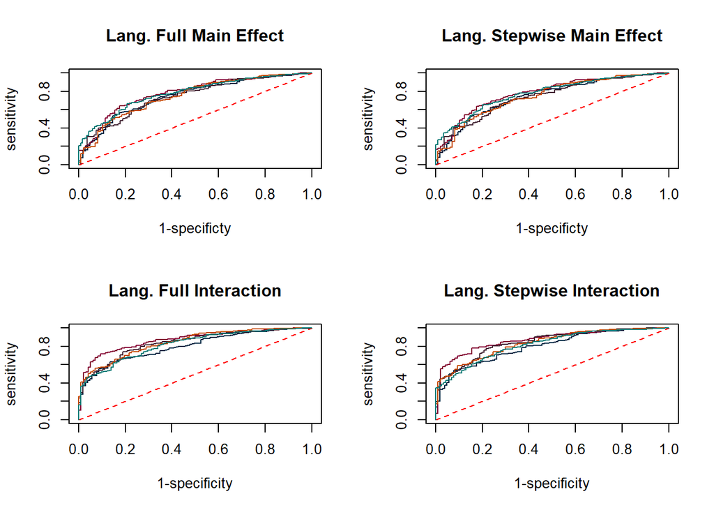

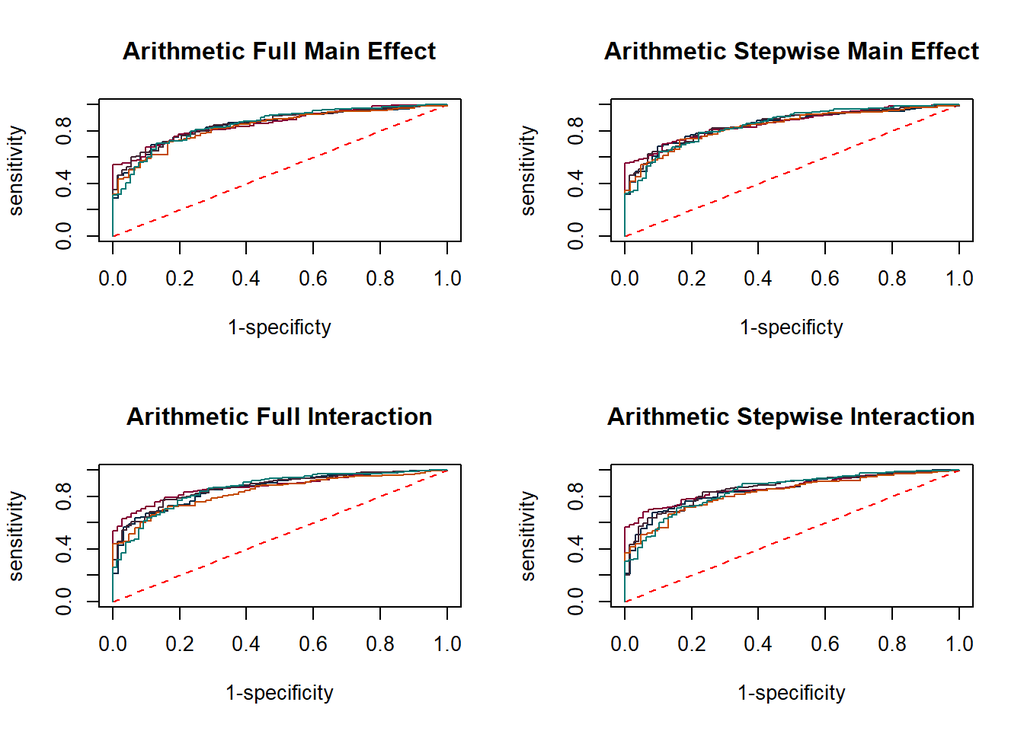

The ROC curves for the Language interaction models look considerably better than the main effect models, while no obvious difference in performance seems apparent between the full and stepwise models for both. On the other hand, all of the arithmetic ROC curves look very similar.

We can examine the area under the curve for the ROC curves to greater depth in the below tables including the AUC summary statistics:

5-fold Cross-Validated AUC for Language candidate models

|  | Min. | 1st Qu. | Median | Mean | 3rd Qu. | Max. |
| --- | --- | --- | --- | --- | --- | --- |
| Full Main Effect Model | 0.7451 | 0.7461 | 0.7479 | 0.76004 | 0.7790 | 0.7821 |
| Stepwise Main Effect Model | 0.7437 | 0.7459 | 0.7485 | 0.76014 | 0.7792 | 0.7834 |
| Full Interaction Model | 0.7996 | 0.8198 | 0.8367 | 0.83366 | 0.8434 | 0.8688 |
| Stepwise Interaction Model | 0.7981 | 0.8185 | 0.8332 | 0.83272 | 0.8439 | 0.8699 |

5-fold Cross-Validated AUC for Arithmetic candidate models

|  | Min. | 1st Qu. | Median | Mean | 3rd Qu. | Max. |
| --- | --- | --- | --- | --- | --- | --- |
| Full Main Effect Model | 0.8343 | 0.8465 | 0.8496 | 0.84720 | 0.8517 | 0.8539 |
| Stepwise Main Effect Model | 0.8372 | 0.8442 | 0.8473 | 0.84670 | 0.8487 | 0.8561 |
| Full Interaction Model | 0.8362 | 0.8595 | 0.8602 | 0.86036 | 0.8697 | 0.8762 |
| Stepwise Interaction Model | 0.8268 | 0.8460 | 0.8468 | 0.84900 | 0.8583 | 0.8671 |

The stepwise and full models performed similarly enough in all considered metrics for their differences in predictive performance to be considered negligible. As such, the stepwise models are preferred above the full for both the main effect and interaction models for both subjects on the principles of parsimony. Based on the AUC, the differences between the interaction models and main effect models for Language justifies the selection of the interaction model, while the differences between the interaction models and main effect models for Arithmetic do not seem as important. Therefore, the final logistic models for both subjects are the following:

Language: Stepwise Interaction Model Arithmetic: Stepwise Main Effects Model

## Further Specifications

We can maximize the area under the curve for an ROC curve for each of the selected models, and then find the specificity and sensitivity for that point.

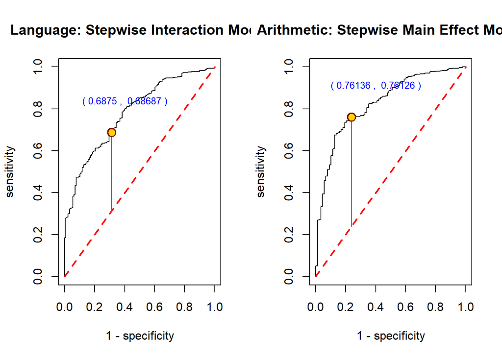

We can also create plots of the accuracy, specificity, and sensitivity of each of these models over different cutoff probabilities as well.

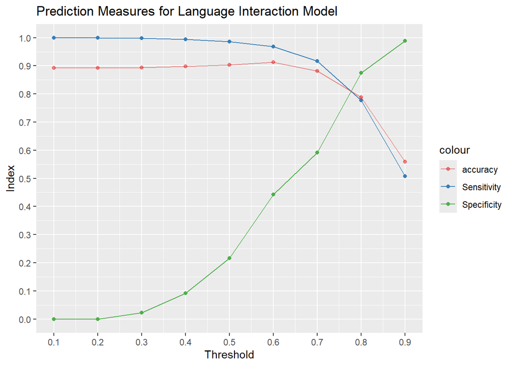

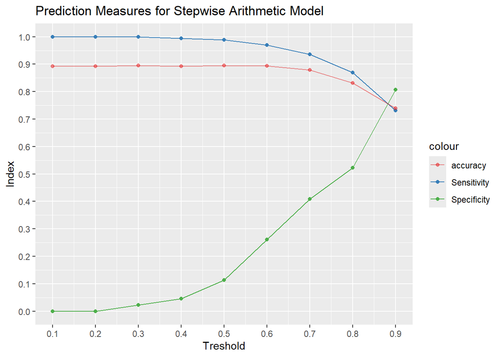

From these graphs, we see that an ideal cutoff probability of about 0.77 for the language models and 0.87 for the arithmetic models maximizes sensitivity and specificity.

We take a final look at the parameter estimates for the two selected models.

Language Improvement Logistic Stepwise Interaction Model Parameter Estimates

|  | Estimate | Std. Error | z value | Pr(>\|z\|) |
| --- | --- | --- | --- | --- |
| (Intercept) | 1.6668519 | 0.1206726 | 13.8130119 | 0.0000000 |
| sex1 | 0.8012155 | 0.1821726 | 4.3981118 | 0.0000109 |
| min1 | 0.6000305 | 0.2970773 | 2.0197792 | 0.0434063 |
| den2 | 0.3308813 | 0.1547745 | 2.1378279 | 0.0325307 |
| den3 | -0.1669390 | 0.1541003 | -1.0833138 | 0.2786692 |
| den4 | 0.4690459 | 0.3766675 | 1.2452520 | 0.2130391 |
| tses | 0.1523072 | 0.0921371 | 1.6530493 | 0.0983208 |
| tssi | 0.0632335 | 0.0589607 | 1.0724690 | 0.2835094 |
| tiqv | 0.1813492 | 0.0598108 | 3.0320468 | 0.0024290 |
| apr | -0.1179500 | 0.0843279 | -1.3987071 | 0.1619008 |
| iqp | -0.2032185 | 0.0687764 | -2.9547729 | 0.0031290 |
| has_repeated_group1 | -0.5020179 | 0.1679044 | -2.9899030 | 0.0027907 |
| tapo | 1.1202457 | 0.0991842 | 11.2946015 | 0.0000000 |
| sex1:den2 | -0.4570286 | 0.2316355 | -1.9730511 | 0.0484897 |
| sex1:den3 | -0.0099298 | 0.2402417 | -0.0413326 | 0.9670308 |
| sex1:den4 | -0.9236706 | 0.5360329 | -1.7231604 | 0.0848595 |
| sex1:apr | 0.2017032 | 0.1237583 | 1.6298150 | 0.1031406 |
| sex1:tapo | -0.2318731 | 0.1311260 | -1.7683219 | 0.0770071 |
| min1:tses | 0.5087286 | 0.2096014 | 2.4271237 | 0.0152191 |
| min1:tssi | -0.4270360 | 0.1814359 | -2.3536470 | 0.0185903 |
| den2:tses | -0.1988805 | 0.1120345 | -1.7751723 | 0.0758694 |
| den3:tses | -0.0570852 | 0.1207752 | -0.4726566 | 0.6364582 |
| den4:tses | 0.7884426 | 0.3036920 | 2.5961917 | 0.0094263 |
| tses:tssi | -0.1829103 | 0.0497905 | -3.6735983 | 0.0002392 |
| tses:iqp | 0.0836591 | 0.0580539 | 1.4410583 | 0.1495682 |
| tses:tapo | 0.1047601 | 0.0672718 | 1.5572660 | 0.1194073 |
| apr:iqp | -0.1359372 | 0.0610653 | -2.2260960 | 0.0260078 |
| apr:tapo | 0.2024796 | 0.0692151 | 2.9253671 | 0.0034405 |
| iqp:has_repeated_group1 | 0.2358161 | 0.1409126 | 1.6734917 | 0.0942305 |
| has_repeated_group1:tapo | -0.3160075 | 0.1664020 | -1.8990601 | 0.0575566 |

Arithmetic Improvement Logistic Stepwise Main Effects Model Parameter Estimates

|  | Estimate | Std. Error | z value | Pr(>\|z\|) |
| --- | --- | --- | --- | --- |
| (Intercept) | 3.2057049 | 0.1125474 | 28.483163 | 0.0000000 |
| sex1 | -0.5561029 | 0.1176502 | -4.726747 | 0.0000023 |
| tssi | 0.2329103 | 0.0577382 | 4.033902 | 0.0000549 |
| tlpr | -0.1207150 | 0.0853155 | -1.414924 | 0.1570906 |
| iqp | 0.4885369 | 0.0686741 | 7.113842 | 0.0000000 |
| has_repeated_group1 | -0.3327376 | 0.1362473 | -2.442160 | 0.0145997 |
| tlpo | 1.1613681 | 0.0957747 | 12.126043 | 0.0000000 |

# Summary and Discussion

The final models chosen were the following:

Multiple Linear Regression: The stepwise main effect model was chosen for efficiency and predictive potential, as there were not particularly obvious benefits in using any of the more complex models for the prediction of the student’s total combined post-test score for Arithmetic and Language. There appeared to be possible violations to the assumption of homogeneity of variance for multiple linear regression; however, this may be attributable to the sparsity of observations for extreme values in the population compared to the bulk of the observations in the middle. The stepwise reduced interaction models were recommended for more insight into the school and individual related features and how they relate to each other in the prediction of post-test score.

Logistic Regression: Logistic regression models were created to predict for a positive change in score in each of the subjects of Language and Arithmetic for each student. The stepwise reduced main effect model was recommended for the prediction of a positive change in arithmetic score, and the stepwise reduced interaction model was recommended for the prediction of a positive change in language score. Different cut-off probabilities were recommended to maximize the specificity and sensitivity of predictions.

# References

1. https://xiang-a.github.io/sta552-project1/
2. https://xiang-a.github.io/sta552-hw2/